# LBOMETR Problem Set 2

Author

Rocky John R. Mina Jr.

Published

March 19, 2024

```r
# Load necessari libraries
library(readxl)
library(tidyverse)
library(summarytools)
library(ggplot2)
library(dplyr)
library(lubridate)
library(psych)
library(car)
library(boot)
library(wooldridge)
```

# I. Data Cleaners: Navigating Data Cleaning

## **a. Five most Common Surnames among South Korean-born K-pop idols**

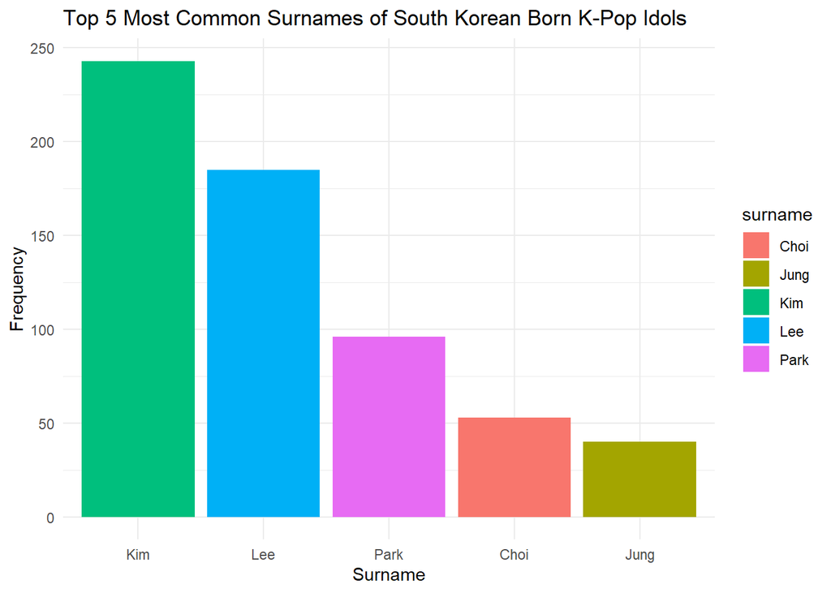

```r
# Load the data
data_kpop <- read_excel("kpop_idols.xlsx")

# Extract Family name
data_kpop$surname <- sapply(strsplit(data_kpop$"Full Name", " "), `[`, 1)

# Seperate South Korean born idols
data_foreign <- data_kpop %>% filter(Country != "South Korea")
data_KR <- data_kpop %>% filter(Country == "South Korea")

# Count the frequency of each surname
surname_counts <- data_KR %>%
    group_by(surname) %>%
    summarise(count = n()) %>%
    arrange(desc(count))

# Find the five most common surnames
top_surnames <- head(surname_counts, 5)

# Plotting the top five surnames
ggplot(top_surnames, aes(x = reorder(surname, -count), y = count, fill = surname)) +
  geom_bar(stat = "identity") +
  labs(title = "Top 5 Most Common Surnames of South Korean Born K-Pop Idols",
       x = "Surname",
       y = "Frequency") +
  theme_minimal()
```

## b. Average membership size of male and female groups

```r
# Filtering the data
filtered_data <- data_kpop %>%
  filter(Group != "", !is.na(Group)) %>%  # Filters group that are not empty or missing
  add_count(Group) %>%
  filter(n > 1) %>% # keeps only those appear more than once
  select(-n)  # Remove the added count column


# Count the number of members in each group while considering the gender
group_sizes <- filtered_data %>%
  group_by(Group, Gender) %>%
  summarise(member_count = n(), .groups = 'drop')

# Separate Male and Female
group_sizes_M <- group_sizes %>% filter(Gender == "M")
group_sizes_F <- group_sizes %>% filter(Gender == "F")

# Get the mean
mean_M <- mean(group_sizes_M$member_count)
mean_F <- mean(group_sizes_F$member_count)

cat("Average member count for male groups:", mean_M, "\n")
```

```
Average member count for male groups: 6.33
```

```r
cat("Average member count for female groups:", mean_F)
```

```
Average member count for female groups: 5.5
```

Average member count for male groups: 6.33

Average member count for female groups: 5.5

### b.1.

The results suggest that, on average, male groups in the Kpop scene tend to have more members than female groups albeit the difference is little. One possible explanation for this is that, there are more male in kpop than female (633 > 583) [we easily computed this using `` sum(group_sizes_M[3]);``sum(group_sizes_F[3]) ``]. Since there are more males, groups will naturally form with more members.

Another more practical explanation may be because male groups tend to be more dance-focus. A higher member count is generally more favored when it comes to performing dance routines.

## c. Male Idols qualified for military service

```r
# Check the datatype of the date
# class(data_kpop$"Date of Birth")  -----  This returns POSIXct

reference_date <- as.POSIXct(Sys.Date(), tz = "UTC") # We used Sys.Date() to extract the date today (date from the computer)
data_kpop$age <- floor(as.numeric(difftime(reference_date, data_kpop$"Date of Birth", units = "days")) / 365.25) # Since we are dealing with age, we will use the floor() function to round down.

# Separete Male idols
data_kpop_M <- data_kpop %>% filter(Gender == "M")

# Filter male idols between age 18 and 28
data_kpop_M_military <- data_kpop_M %>% filter(age >= 18 & age <= 28)

# Count how many idols age 18-28
count_M_military <- nrow(data_kpop_M_military)
cat("There are", count_M_military, "male idols eligible for military service")
```

```
There are 385 male idols eligible for military service
```

There are **385** male idols eligible for military service

### c.1

```r
# Filter male idols between age 18 and 28
data_kpop_M_military <- data_kpop_M %>% filter(age >= 18 & age <= 28)
```

The idol I am not looking forward in leaving for military service is CIX’s Bae Jinyoung. I’ve been supporting him since Produce 101 S2, his debut in Wanna One, and his re-debut in CIX. Even during the times he would be doing his military service, I would still be supporting his group to support the other members. That means that regardless if he is present or not, the consumption would be the same.

# II. Bootstrap Brigadiers: Champions of Sampling Expeditions

## a. Bootstrapping (bivariate)

```r
data(beauty)

rsq_function <- function(formula, data, indices) {
  sampled_data <- data[indices, ] #allows boot to select sample
  fit <- lm(formula, data = sampled_data)
return(summary(fit)$r.square)
}
#perform bootstrapping with 3000 replications
reps<-boot(data=beauty, statistic=rsq_function, R=3000, formula=lwage ~ union)
reps
```

```
ORDINARY NONPARAMETRIC BOOTSTRAP


Call:
boot(data = beauty, statistic = rsq_function, R = 3000, formula = lwage ~
    union)


Bootstrap Statistics :
      original       bias    std. error
t1* 0.03135535 0.0004735055 0.008864092
```

Looking at the bootstrap statistics, we can see that we have a positive bias. This means that the bootstrap estimate on average is higher than the original estimate. Now, relative to the bootstrap estimates, the standard error here is high. This means that there is high variability in the bootstrap estimates.

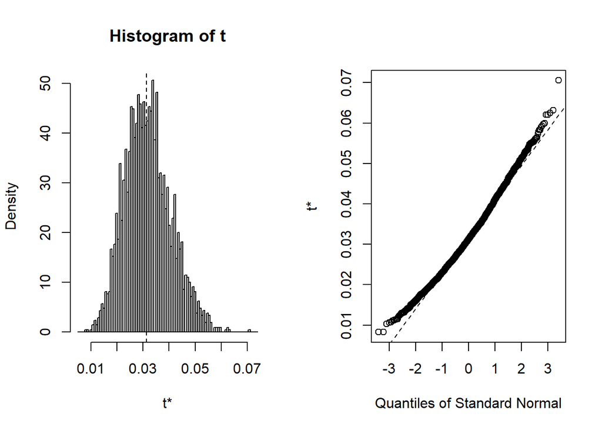

```r
plot(reps)
```

The histogram suggests slight deviation to normality. It also clearly shows that it is skewed to the right which shows that there is bias in the estimate (which is shown in the bootstrap statistics as well). The Q-Q plot on the other hand shows that bootstrap estimates are close to normal with just slight deviation.

```r
conf_int <- boot.ci(reps, type = "bca")
print(conf_int)
```

```
BOOTSTRAP CONFIDENCE INTERVAL CALCULATIONS
Based on 3000 bootstrap replicates

CALL :
boot.ci(boot.out = reps, type = "bca")

Intervals :
Level       BCa
95%   ( 0.0163,  0.0510 )
Calculations and Intervals on Original Scale
```

### a.1 Are the R-squared Similar?

The R-squared from the bivariate regression in Problem Set 1 is `0.03059` This is NOT equal to the bootstrap value which is `0.03135535` .

## b. Bootstrapping (Multivariate)

```r
rsq2_function <- function(formula, data, indices) {
  sampled_data2 <- data[indices, ] #allows boot to select sample
  fit <- lm(lwage ~union + female + bigcity, data = sampled_data2)
  return(summary(fit)$r.square)
}

#perform bootstrapping with 3000 replications
reps2<-boot(data=beauty, statistic=rsq2_function, R=3000, formula=lwage ~union + female + bigcity)
reps2
```

```
ORDINARY NONPARAMETRIC BOOTSTRAP


Call:
boot(data = beauty, statistic = rsq2_function, R = 3000, formula = lwage ~
    union + female + bigcity)


Bootstrap Statistics :
     original      bias    std. error
t1* 0.2389014 0.002038595  0.01980464
```

Looking at the bootstrap statistics, we can see that we have a positive bias. This means that the bootstrap estimate on average is higher than the original estimate. Relative to the bootstrap estimates, the standard error here is low. This means that there is low variability in the bootstrap estimates.

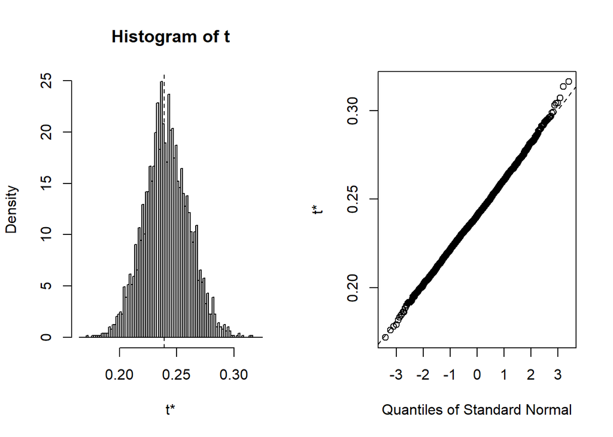

```r
plot(reps2)
```

The histogram suggests the distribution is close to normal. It also shows that it is slightly skewed to the right which shows that there is bias in the estimate (which is shown in the bootstrap statistics as well). The Q-Q plot on the other hand shows that the distribution of the bootstrap estimates is very close to normal.

```r
conf_int2 <- boot.ci(reps2, type = "bca")
print(conf_int2)
```

```
BOOTSTRAP CONFIDENCE INTERVAL CALCULATIONS
Based on 3000 bootstrap replicates

CALL :
boot.ci(boot.out = reps2, type = "bca")

Intervals :
Level       BCa
95%   ( 0.1993,  0.2772 )
Calculations and Intervals on Original Scale
```

### b.1. Are the R-squared Similar?

The R-squared from the multivariate regression in Problem Set 1 is `0.2389` which is EQUAL to the bootstrap value which is `0.2389014`

## c. Bootstrapping vs Monte Carlo

Both are simulations that uses re-sampling techniques to analyze the variables. Monte Carlo is often utilized for testing estimators’ performance by generating random samples from known or assumed distributions, whereas bootstrapping estimates statistic variability and its sampling distribution shape by resampling with replacement from observed data. So, the choice between the two really depends on the objective of the analysis.

Additionally, in our case, it seems that the more independent variables we add, the more the two methods converge in terms of their R-squared values.

# III. The Significance Seekers: Sagas of Hypothesis Testing

1. A company reports that last year, 40% of their reports in accounting were on time. From a random sample this year, they want to know if that proportion has changed.

   H0: The proportion of accounting reports that were on time has not changed, i.e., equal to 40%.

   H1: The proportion of accounting reports that were on time has changed, i.e., not equal to 40%.

   Since we are only concerned if the proportion has changed, then the test must be two-tailed. Furthermore, since we are comparing a sample proportion (the proportion of on-time-reports this year) to a known population proportion (40%), we will use single one-sample test of proportion. The code is given by,

   `prop.test(x="numberOfontimereports", n="sampleSize", p="0.40", correct=FALSE) #False indicate s no continuity correction used`
2. The average age of a customer of a clothing store is 35.2 years. The company wants to know if customers who use their website are younger on average.

   H0: The average age of a customer of a clothing store is 35.2 years.

   H1: The average age of a customer of a clothing store is younger than 35.2 years.

   Since we want to know if the customers are younger than average, we will use one-tailed test. Since we are comparing the mean of the sample test to a given number, we will use single-sample t-test. The code is given by,

   `set.seed(0)`

   `n<- 'sample size' #this is the sample size of the customers`

   `sample<-runif(n, min=min, max=max) #this is to create samples`

   `` t.test(sample, mu=35.2,``alternative="less"``) #mu is the average age we supply ``

   *We used “less” here since we need to know if the customers are younger on average as stated in alternative hypothesis.
3. In two separate polls conducted 6 months apart, constituents were asked if they approved of the job their president was doing. Is there significant evidence that his approval rating has increased

```
Approval ratings are measured by percentage, hence, we are concerned about proportions here.

H0: There is no significant difference in the proportion of constituents approving of the president's job between the two polls.

H1: The proportion of constituents approving of the president's job has increased.

Since we are concerned if the approval ratings increased, we will use one-tailed test. Since the polls are independent of each other, i.e., different respondents, we will use the two-sample proportion test. The code is given by,

`x1 <- # Number of approvals in the first poll`

`n1 <- # Total number of respondents in the first poll`

`x2 <- # Number of approvals in the second poll`

`n2 <- # Total number of respondents in the second poll`

`prop.test(x = c(x1, x2), n= c(n1, n2), alternative = "greater", correct = FALSE)`

We used greater here since we want to know if the approval ratings increased.
```

4. A factory claims that less than 10% of the components they produce are defective. A consumer group is skeptical of the claim and checks a SRS of 300 components and finds that 39 are defective. Is there significant evidence to reject the companiesʼ claim?

   H0: The proportion of defective components produced by the factory is less than 10%.

   H1: The proportion of defective components produces by the factory is greater than or equal to 10%.

   Since we are concerned if the proportion of defective components is greater, we will use one-tailed test. Since the we are comparing a sample from the consumer group to a proportion claimed by the company, we will use one-sample proportion test. The code is given by

   `defective_count <- 39`

   `total_components <- 300`

   `null_proportion <- 0.10 # proportion claimed by the comapny`

   `` prop.test(x = defective_count, n = total_components, p = null_proportion, alternative = "greater",``correct = FALSE``) ``

# IV. The Dummy Variable Deacons: Chronicles of Categorical Coding

## Preliminaries

```r
# Load required data
data_quota <- read_csv("quotas.csv", show_col_types = FALSE)


# Creating a new column ,, SC = 1 , Otherwise = 0
data_quota <- data_quota %>%
  mutate(SC_column = ifelse(is.na(AC_type_noST) | AC_type_noST != "SC", 0, 1))
```

## a. Descriptive Statistics and Histogram

```r
describe(data_quota$SC_column)
```

```
   vars    n mean   sd median trimmed mad min max range skew kurtosis   se
X1    1 3134 0.15 0.36      0    0.07   0   0   1     1 1.92     1.67 0.01
```

The descriptive statistics shows that there are 3134 data points in the data. Since this is a dummy variable, the mean represents the proportion of the number of SCs to the total number of seats (15%). The standard deviation does not provide us any meaningful interpretation about the spread of the data since there are only two possible values. This is also the case for the median, min, max, etc.

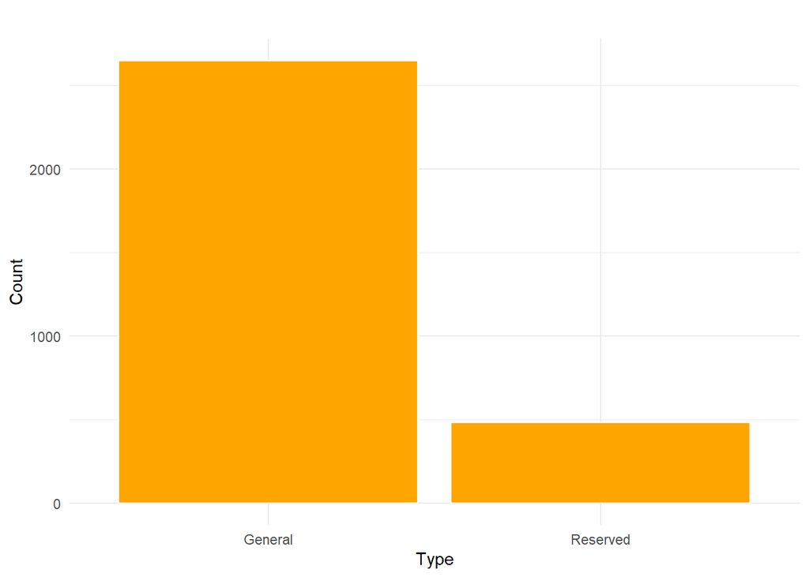

```r
# Convert SC_column to a factor so that it can be used in ggplot with labels
data_quota$SC_column <- factor(data_quota$SC_column)

# Now plot the data
ggplot(data = data_quota, aes(x = SC_column)) +
  geom_bar(color = "white", fill = "orange") +
  scale_x_discrete(labels = c("General", "Reserved")) +
  theme_minimal() +
  labs(
    title = "",
    x = "Type",
    y = "Count"
  ) +
  theme(
    plot.title = element_text(color = "darkred", size = 14, face = "italic")
  )
```

## b. T-test

```r
# Creating subset to for SC and non SC
reserved_data <- subset(data_quota, SC_column == 1)
general_data <- subset(data_quota, SC_column == 0)

# Print
cat("Number of SCs:", nrow(reserved_data),"\n")
```

```
Number of SCs: 483
```

```r
cat("Number of non SCs:", nrow(general_data),"\n\n")
```

```
Number of non SCs: 2651
```

Since the length of these two are not the same, we will use independent t-test

```r
# We will check first the variances
var.test(reserved_data$P_educVD01_sc, general_data$P_educVD01_sc)
```

```
    F test to compare two variances

data:  reserved_data$P_educVD01_sc and general_data$P_educVD01_sc
F = 1.3831, num df = 477, denom df = 2597, p-value = 1.662e-06
alternative hypothesis: true ratio of variances is not equal to 1
95 percent confidence interval:
 1.208572 1.593376
sample estimates:
ratio of variances
          1.383077
```

Since the variance test result is not equal to 1, we will use var.equal = FALSE

```r
# Performing t-test
ttest_result <- t.test(reserved_data$P_educVD01_sc, general_data$P_educVD01_sc, var.equal = FALSE)
print(ttest_result)
```

```
    Welch Two Sample t-test

data:  reserved_data$P_educVD01_sc and general_data$P_educVD01_sc
t = -2.8767, df = 610.37, p-value = 0.004159
alternative hypothesis: true difference in means is not equal to 0
95 percent confidence interval:
 -2.0739158 -0.3910923
sample estimates:
mean of x mean of y
 94.20136  95.43386
```

### b.1.

Overall, with a p-value of 0.004159, we will reject the null hypothesis. This means that there is evidence to suggest that there is a statistically significant difference in the mean of SC and non SCs in rural areas living in villages with an educational institution between the two groups defined by the SC_column variable.

## c. OLS Regression

```r
# Creating the model WITH Control Variables
model <- lm(P_educVD01_sc ~ SC_column + tot_pop71_true + SC_percent71_true + Plit71+ Plit71_SC + P_W71 + P_al71_SC + P_al71_nonSC, data = data_quota)

summary(model)
```

```
Call:
lm(formula = P_educVD01_sc ~ SC_column + tot_pop71_true + SC_percent71_true +
    Plit71 + Plit71_SC + P_W71 + P_al71_SC + P_al71_nonSC, data = data_quota)

Residuals:
    Min      1Q  Median      3Q     Max
-97.023  -0.987   2.141   3.955  11.247

Coefficients:
                    Estimate Std. Error t value Pr(>|t|)
(Intercept)        8.976e+01  1.308e+00  68.647  < 2e-16 ***
SC_column1         5.620e-02  4.147e-01   0.136   0.8922
tot_pop71_true    -1.900e-05  4.234e-06  -4.487 7.47e-06 ***
SC_percent71_true -9.327e-02  1.961e-02  -4.755 2.07e-06 ***
Plit71            -3.455e-02  2.225e-02  -1.553   0.1206
Plit71_SC          1.819e-01  2.635e-02   6.904 6.11e-12 ***
P_W71              1.949e-01  2.577e-02   7.562 5.20e-14 ***
P_al71_SC          5.023e-02  8.667e-03   5.796 7.47e-09 ***
P_al71_nonSC      -5.002e-02  1.564e-02  -3.198   0.0014 **
---
Signif. codes:  0 '***' 0.001 '**' 0.01 '*' 0.05 '.' 0.1 ' ' 1

Residual standard error: 7.366 on 3067 degrees of freedom
  (58 observations deleted due to missingness)
Multiple R-squared:  0.09051,   Adjusted R-squared:  0.08814
F-statistic: 38.15 on 8 and 3067 DF,  p-value: < 2.2e-16
```

```r
# Creating the model WITHOUT Control Variables
model2 <- lm(P_educVD01_sc ~ SC_column, data = data_quota)
summary(model2)
```

```
Call:
lm(formula = P_educVD01_sc ~ SC_column, data = data_quota)

Residuals:
    Min      1Q  Median      3Q     Max
-95.434  -1.573   3.276   4.566   5.799

Coefficients:
            Estimate Std. Error t value Pr(>|t|)
(Intercept)  95.4339     0.1511 631.560  < 2e-16 ***
SC_column1   -1.2325     0.3833  -3.215  0.00132 **
---
Signif. codes:  0 '***' 0.001 '**' 0.01 '*' 0.05 '.' 0.1 ' ' 1

Residual standard error: 7.702 on 3074 degrees of freedom
  (58 observations deleted due to missingness)
Multiple R-squared:  0.003352,  Adjusted R-squared:  0.003028
F-statistic: 10.34 on 1 and 3074 DF,  p-value: 0.001317
```

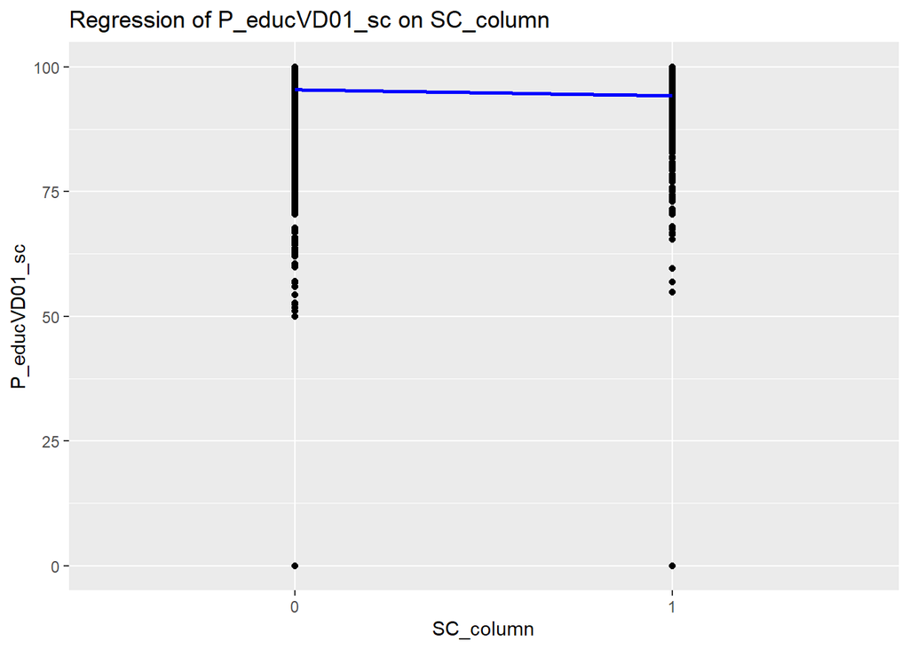

```r
# Plot without control variable
ggplot(data = data_quota, aes(x = SC_column, y = P_educVD01_sc)) +
  geom_point() +  # Add points
  geom_smooth(method = "lm", se = FALSE, aes(group = 1), color = "blue") +  # Add regression line only for SC_column
  labs(title = "Regression of P_educVD01_sc on SC_column",
       x = "SC_column",
       y = "P_educVD01_sc")
```

### c.1.

With the SC_column getting a p-value of 0.8922, it is evident that this is **NOT** less than 0.05. This means that there is **not enough evidence** to suggest that places with reserved constituencies has significant effect on the percentage of SCs in rural areas in AC living in a village with education institution. R-squared of the regression is 0.09051 which suggests that even with the control variables, the fit of the line is still not that good.

Including control variables improves the internal validity of a study by mitigating the impact of confounding and other extraneous variables. The control variables that we included are associated with various socioeconomic and demographic factors which could all influence the interaction between the two main variables. By including these, we can isolate the effects of specific independent variable(s) better.

In connection to this, we see that the results *‘plot and summary without control variable’* are very different than the one with control variables. The R-squared is significantly less, which means that the fit is also worse. Hence, without the control variables, we found out that we cannot get valuable results from the regression.

## d. Variance inflation factor test

```r
# Get vif values using vif() from 'car' package
vif_values <- vif(model)

# We'll transform this to a data frame for easier viewing
vif_df <- data.frame(VIF = vif_values)
vif_df
```

```
                       VIF
SC_column         1.279635
tot_pop71_true    1.083554
SC_percent71_true 1.602919
Plit71            4.391176
Plit71_SC         4.627522
P_W71             1.245017
P_al71_SC         2.248718
P_al71_nonSC      2.337021
```

### d.1 Interpreting VIF

The VIF values are used to detect multicollinearity among predictor variables. A value of 1 indicates no correlation. A value between 1 and 5 typically means moderate correlation among predictors, but this is often not severe enough to require attention. Value greater than 5 are considered to be severe, and most of the time makes the p-value and estimates unreliable.

In our case, we see that none of the predictors has more than 5 VIF. The highest one, 4.627522, is Plit71_SC (Literacy rate among SCs in AC) which signifies moderate correlation. While to lowest is 1.083554, which is tot_pop71_true (Total population in an AC) signifies little to no correlation.

## e.Breusch-Pagan Test

```r
lmtest::bptest(model)
```

```
    studentized Breusch-Pagan test

data:  model
BP = 39.74, df = 8, p-value = 3.581e-06
```

## e.1 Interpretation of the Breusch-Pagan Test

The test detects if there is heteroskedasticity in the model.

The null hypothesis of the studentized Breusch-Pagan test is that there is no heteroskedasticity present in the regression model.

The alternative hypothesis is that there is heteroskedasticity present in the regression model.

The p-value is less than 0.05. this means that we reject the null hypothesis and this means that heteroskedasticity is present in our data, i.e. it violates our assumption. This indicates that our result may not be reliable.

## f. Ramsay RESET Test

```r
lmtest::resettest(model)
```

```
    RESET test

data:  model
RESET = 10.417, df1 = 2, df2 = 3065, p-value = 3.1e-05
```

## f.1 Interpretation of the Ramsay RESET test

The test detects if there is specification error in the model.

The null hypothesis of the RESET test is that the regression model is correctly specified.

The alternative hypothesis is that there is specification error in the regression model.

The p-value is less than 0.05. this means that we reject the null hypothesis. This suggests that there is evidence of specification error in the regression model. It may be that the functional form is inappropriate, or the choice of independent variables does not represent the true data-generating process. This indicates that our result may not be reliable.

# V. The Econometrics Pilgrims: Navigating the Data Frontier

**Research Topic**

Impact of Academic Performance at the Undergraduate Level on First Salary

**Objectives**

This research focuses on how academic performance during undergraduate studies translates into real-world career opportunities and financial rewards. It is quite a common perception that firms offer more salary to people who did well during their undergrad. Similarly, it is also common for fresh graduates to be more confident in negotiating their salary if they have high academic performance. With this, the specific objective of this research is to assess whether high academic achievement during undergraduate studies correlates with higher initial salary offers.

**Variables**

Independent Variable:

- Academic Performance [1 = Latin Honors/High GPA, 0 = Low GPA]

Dependent Variable:

- First Salary [1 = High Salary (we may define this further as higher than median first salary), 0 = Low Salary (i.e., lower than median first salary)

Control Variables:

- Displince [0 = STEM, 1 = Liberal Arts, 2 = Business, etc.]
- University Reputation [1 = Within top 10 in the coutnry, 0 = Otherwise]
- Conduct [1 = Good Moral, 0 = Otherwise]
- Extracurriculars [1 = Active, 0 = No participation]

**Null and Alternative Hypotheses:**

H0: There is no significant relationship between academic performance during undergraduate studies and the first salary obtained by graduates.

H1: There is a significant relationship between academic performance during undergraduate studies and the first salary obtained by graduates.